# STA6856 Time Series

Midterm Project

Author

Hector Gavilanes

## Instructions:

The take-home project exam will involve analyzing time series data. You are allowed to use your notes, the lectures notes, and anything you find in the library or online, if that is properly acknowledged, but all your work must be your own. **Complete this examination honestly, without giving assistance to anyone or receiving it from anyone.**

> UWF Student Code of Academic Conduct: As Argonauts, we act with integrity. We do not lie, cheat, steal, or tolerate those who do.

> I understand that a breach of the UWF Student Code of Academic Conduct will result in disciplinary action, including failing the exam and the course.

> Student Initials: HG
- Failing to submit HTML and QMD files separately will result in failing the exam.

# Exam

```r
#install.packages("astsa")
# Load packages
library(itsmr) # load
library(astsa) # load
library(tidyverse)
library(tsibble)
library(feasts)
library(car)
```

## Problem A: Application of ACVF and ACF

Let’s consider the moving average model MA(1):

$$X_t = \theta Z_{t-1} + Z_t; Z_t \sim WN(0,1)$$

1. Find the autocovariance function -ACVF- of MA(1)
2. Find the autocorrelation function -ACF- of MA(1)
3. Assume $\theta=0.47$ compute the ACVF and ACF.

```r
theta = 0.47
sigma2 = 1
# MA(1)
# ACVF
acvf0 = (1+theta^2)*sigma2
acvf1 = theta*sigma2

# Print vector format
ACVF = c(acvf0, acvf1)
ACVF
```

```
[1] 1.2209 0.4700
```

```r
# ACF
acf0 = 1
acf1 = theta / (1+theta^2)

# Print vector format
ACF = c(acf0, acf1)
ACF
```

```
[1] 1.0000000 0.3849619
```

## Problem B: Application of CI

Consider $X_t$ is a time series AR(1) with $\phi=0.5$ and $\sigma_{Z_t}=2$. Let’s assume we have a sample $\{X_1,\dots,X_{50}\}$. The sample mean is 1.5 and $\hat{\rho}(1)$ (ACF at lag 1) is equal to $0.63$.

The approximate $95\%$ confidence interval for the mean of AR(1) process is given by:

$$\overline{X}_n \pm 1.96 \frac{\sigma_{Z_t}}{\sqrt{n}(1-\phi)}$$

1. Compute the approximate $95\%$ confidence interval for the process mean $\mu_{X_t}$.

```r
xbar = 1.5
phi = 0.5
sigmaZt = 2
n = 50

lb = xbar - 1.96*sigmaZt / (sqrt(n)*1-phi)
ub = xbar + 1.96*sigmaZt / (sqrt(n)*1-phi)
c(lb, ub)
```

```
[1] 0.9034455 2.0965545
```

2. Are the data compatible with the hypothesis that $\mu=0$?
- Data is not compatible with the mean hypothesis equal 0.

The approximate $95\%$ confidence interval for the autocorrelation coefficient at Lag 1, $\rho(1)$, of AR(1) process is given by:

$$\hat{\rho}(1) \pm 1.96 \sqrt{\frac{w_{11}}{n} }$$

where $w_{ii}$ for AR(1) is given by:

$$w_{ii}=\frac{(1-\phi^{2i})(1+\phi^2)}{1-\phi^2} - 2i\phi^{2i}, \quad i=1,2, \dots$$

1. Compute the approximate $95\%$ confidence interval for the autocorrelation coefficient at Lag 1, $\rho(1)$.

```r
rhohat = 0.63
n = 50
phi = 0.5
w11 = 1-phi^2

# CI 95%
lb1 = rhohat - 1.96* (sqrt(w11/n))
ub1 = rhohat + 1.96* (sqrt(w11/n))
c(lb1, ub1)
```

```
[1] 0.38995 0.87005
```

2. Assume we observed $X_{50}=10$. Find the best linear predictor of $X_{52}$

```r
# Prediction
xbar = 1.5
x50 = 10
rho2 = phi^2 #AR(1): ACF at lag 2 = phi^h

# Using the mean sample
x52 = xbar + rho2*(x50 - xbar)
x52
```

```
[1] 3.625
```

## Problem C: ARMA(p,q) Modeling

In this problem we will find an ARMA(p,q) model to the Monthly price of a pound of chicken, US cents per pound. `chicken{astsa}`. Follow these steps:

1. Plot and examine the series and its ACF. Comment.

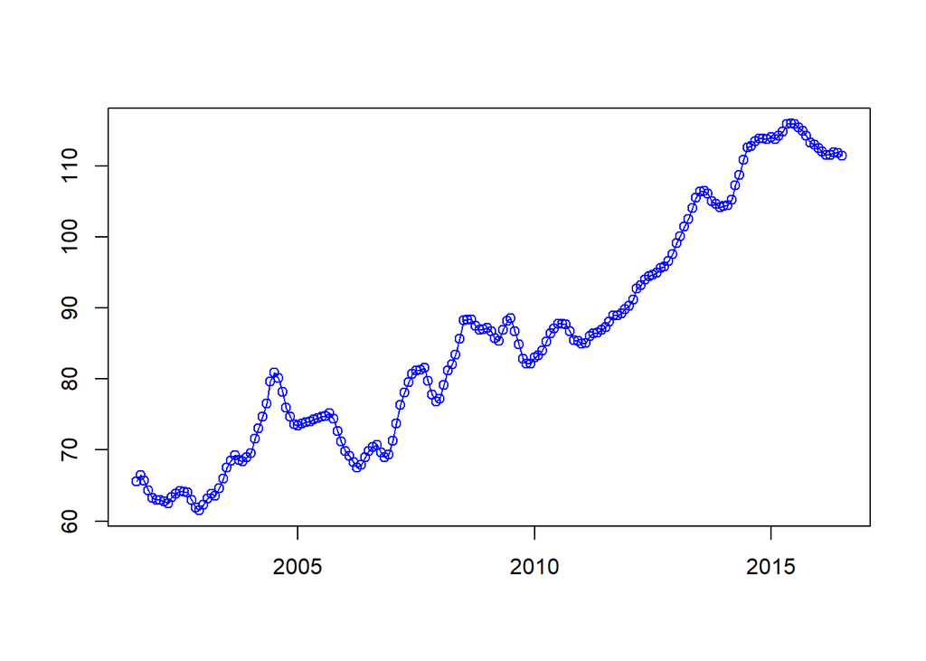

   ```r
   plotc(chicken)
   ```

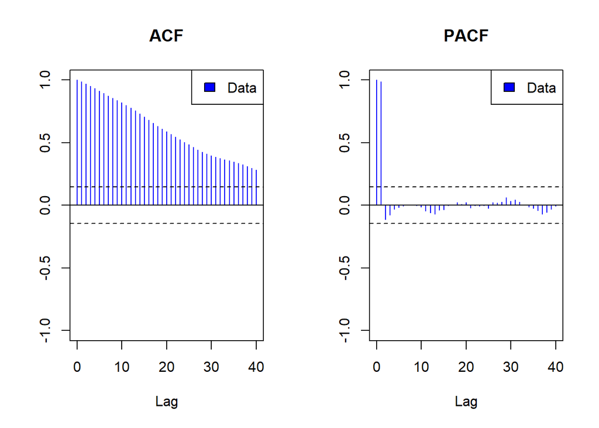

   ```r
   # Plot ACF and PACF
   plota(chicken)
   ```

   The time series has an upward trend, it appears not to have seasonality, and the variance appears to change from high to low volatility.
2. State a data model (components of series observed).

   $$X_t = m_t + Y_t$$

   ```r
   # Data model
   data.model = c("trend", 1) #regression
   ```

   To deal with the variance change, we need to perform a transformation.

   ```r
   lambda = powerTransform(chicken)
   lambda$roundlam
   ```

   ```
   chicken
         0
   ```

   The transformation is going to be log() since lambda = 0.
3. Estimate and Eliminate the components, name the resulting residuals $r1$ (you pick a technique to estimate).

   ```r
   # Eliminate components
   r1 = Resid(chicken, M=data.model)
   ```

4. Eliminate the components using the differencing operator $\nabla$, name the resulting $r2$.

   $$y_t = \nabla^1 + Y_t$$

   ```r
   # Eliminate components using Differencing Operator
   chick_diff = c("diff", 1) # differencing operator
   r2 = Resid(chicken, chick_diff)
   ```

5. Examine the ACF of $r2$. Comment and consider changing your data model, if needed? If you decide to change your data model, then recompute $r1$ and $r2$.

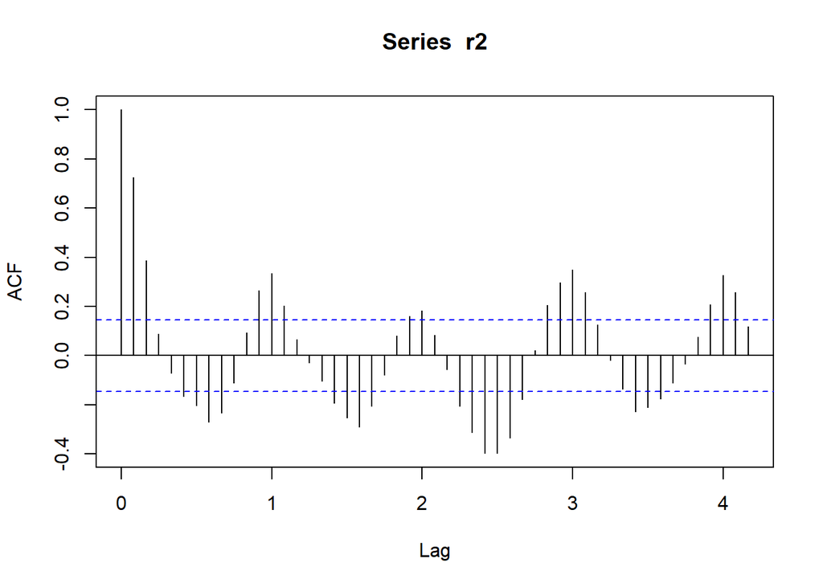

   ```r
   acf(r2, lag.max = 50)
   ```

   The ACF still has some significant values showing on the graph. Thus, the model is not stationary.

## Second Model

   In this case, I will reconsider the model because there is seasonality.

   Recomputing r1, and r2.

   ```r
   # data model
   chick_model = c("trend", 1, "season", 12)
   r1 = Resid(chicken, chick_model)

   # Eliminate components using Differencing Operator
   chick_diff = c("diff", 1, "diff", 12)
   r2 = Resid(chicken, chick_diff)
   ```

6. Test IID hypothesis for the residuals $r1$ and $r2$. Comment.

   ```
   Null hypothesis: Residuals are iid noise.
   Test                        Distribution Statistic   p-value
   Ljung-Box Q                Q ~ chisq(20)   1143.55         0 *
   McLeod-Li Q                Q ~ chisq(20)    646.36         0 *
   Turning points T  (T-118.7)/5.6 ~ N(0,1)        37         0 *
   Diff signs S       (S-89.5)/3.9 ~ N(0,1)        86    0.3675
   Rank P           (P-8055)/404.2 ~ N(0,1)      7993    0.8781
   ```

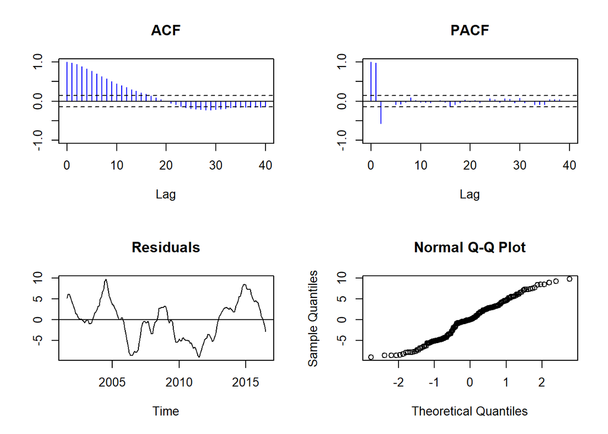

   ```r
   # r1 IID test
   test(r1)
   ```

   ```
   Null hypothesis: Residuals are iid noise.
   Test                        Distribution Statistic   p-value
   Ljung-Box Q                Q ~ chisq(20)    236.56         0 *
   McLeod-Li Q                Q ~ chisq(20)     69.81         0 *
   Turning points T    (T-110)/5.4 ~ N(0,1)        85         0 *
   Diff signs S         (S-83)/3.7 ~ N(0,1)        89    0.1088
   Rank P         (P-6930.5)/361.3 ~ N(0,1)      6323    0.0927
   ```

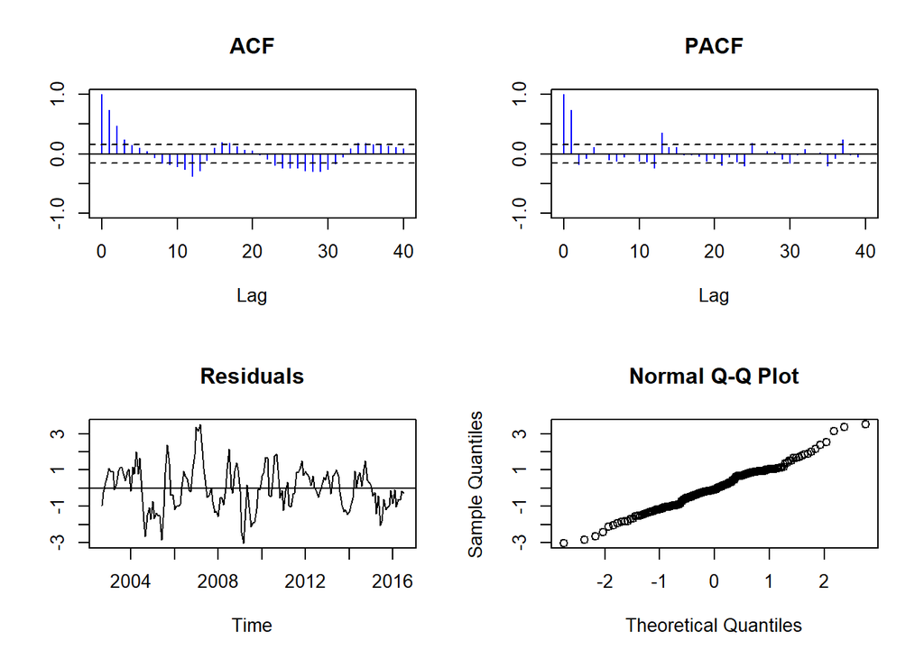

   ```r
   # r2 IID Test
   test(r2)
   ```

   After performing the IID hypothesis test, I can conclude the following:

   Reject $H_0$ at $\alpha = 0.05$. There is sufficient evidence to suggest that the residuals are statistically significant. Thus, the residuals do not comply with the IID hypothesis.

   Further analysis needs to be performed.
7. If the IID hypothesis is rejected, then fit an ARMA(p,q) model to either residuals of your choice.

   p=0,1,6,9,12

   q=0,1,2…

   ```
   Null hypothesis: Residuals are iid noise.
   Test                        Distribution Statistic   p-value
   Ljung-Box Q                Q ~ chisq(20)      32.6    0.0373 *
   McLeod-Li Q                Q ~ chisq(20)     39.19    0.0063 *
   Turning points T    (T-110)/5.4 ~ N(0,1)       117    0.1965
   Diff signs S         (S-83)/3.7 ~ N(0,1)        82    0.7893
   Rank P         (P-6930.5)/361.3 ~ N(0,1)      6898    0.9283
   ```

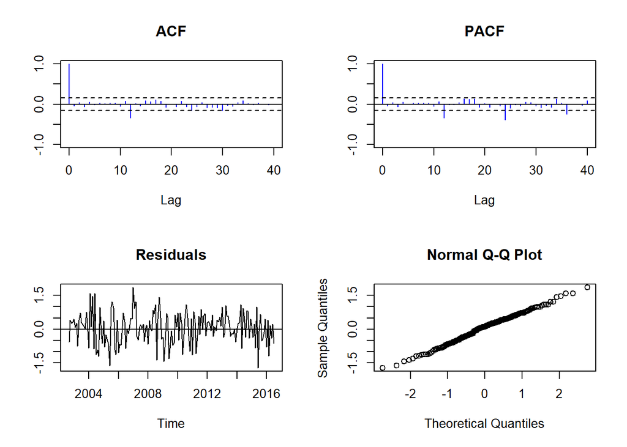

   ```r
   # Model 1
   arma54 = autofit(r2)
   # phi = AR
   # theta = MA

   # Specify
   arma54.model = specify(ar=arma54$phi,
                          ma = arma54$theta,
                          sigma2 = arma54$sigma2)
   test(Resid(x=r2, a=arma54.model))
   ```

8. Present at least 3 models with AIC and IID testing.

## Model-01

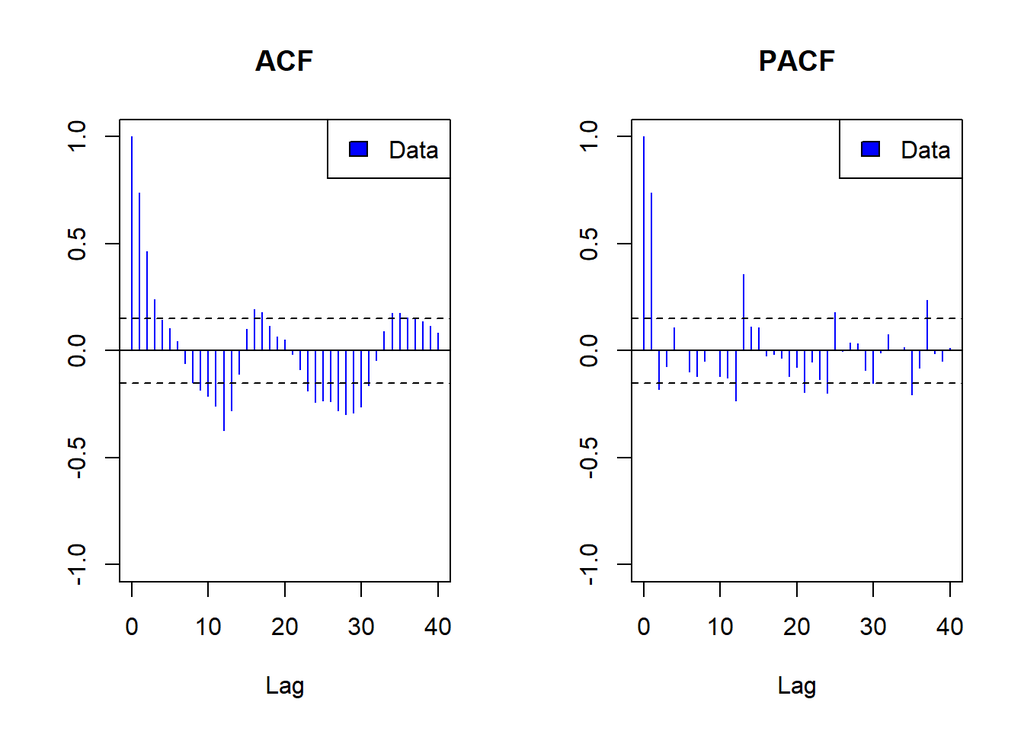

   ```r
   plota(r2)
   ```

   ```
   Null hypothesis: Residuals are iid noise.
   Test                        Distribution Statistic   p-value
   Ljung-Box Q                Q ~ chisq(20)     54.57         0 *
   McLeod-Li Q                Q ~ chisq(20)     28.37     0.101
   Turning points T    (T-110)/5.4 ~ N(0,1)       115    0.3562
   Diff signs S         (S-83)/3.7 ~ N(0,1)        87     0.285
   Rank P         (P-6930.5)/361.3 ~ N(0,1)      6646     0.431
   ```

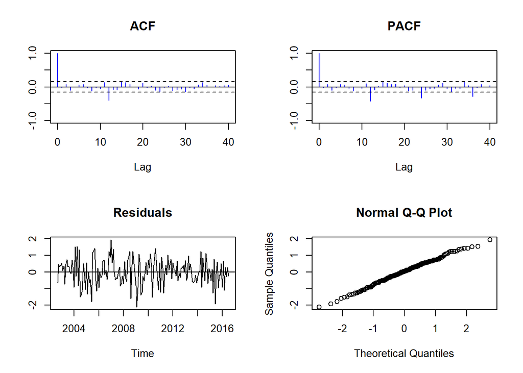

   ```r
   model_1=arma(r2, p=2, q=0)
   arma_model_01 = specify(ar=model_1$phi, ma = model_1$theta, sigma2 = model_1$sigma2)

   arma_resid_01 = Resid(r2, a=arma_model_01)
   test(arma_resid_01)
   ```

## Model-02

   $$Y_t = 0.61Y_{t-1} + 0.29Z_{t-1} + Z_t$$

   ```
   Null hypothesis: Residuals are iid noise.
   Test                        Distribution Statistic   p-value
   Ljung-Box Q                Q ~ chisq(20)     57.96         0 *
   McLeod-Li Q                Q ~ chisq(20)     29.24    0.0831
   Turning points T    (T-110)/5.4 ~ N(0,1)       115    0.3562
   Diff signs S         (S-83)/3.7 ~ N(0,1)        87     0.285
   Rank P         (P-6930.5)/361.3 ~ N(0,1)      6635    0.4134
   ```

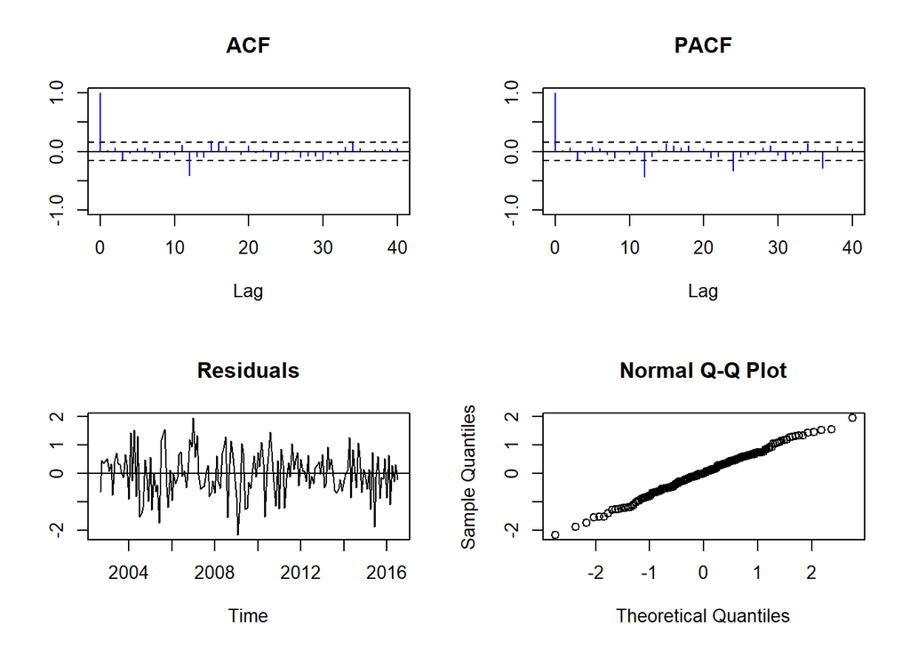

   ```r
   model_2=arma(r2, p=1, q=1)
   arma_model_02 = specify(ar=model_2$phi, ma = model_2$theta, sigma2 = model_2$sigma2)

   arma_resid_02 = Resid(r2, M= NULL, a=arma_model_02)
   test(arma_resid_02)
   ```

## Model-03

   ```
   Null hypothesis: Residuals are iid noise.
   Test                        Distribution Statistic   p-value
   Ljung-Box Q                Q ~ chisq(20)     19.02    0.5205
   McLeod-Li Q                Q ~ chisq(20)     12.94      0.88
   Turning points T    (T-110)/5.4 ~ N(0,1)       112    0.7121
   Diff signs S         (S-83)/3.7 ~ N(0,1)        84    0.7893
   Rank P         (P-6930.5)/361.3 ~ N(0,1)      6748    0.6135
   ```

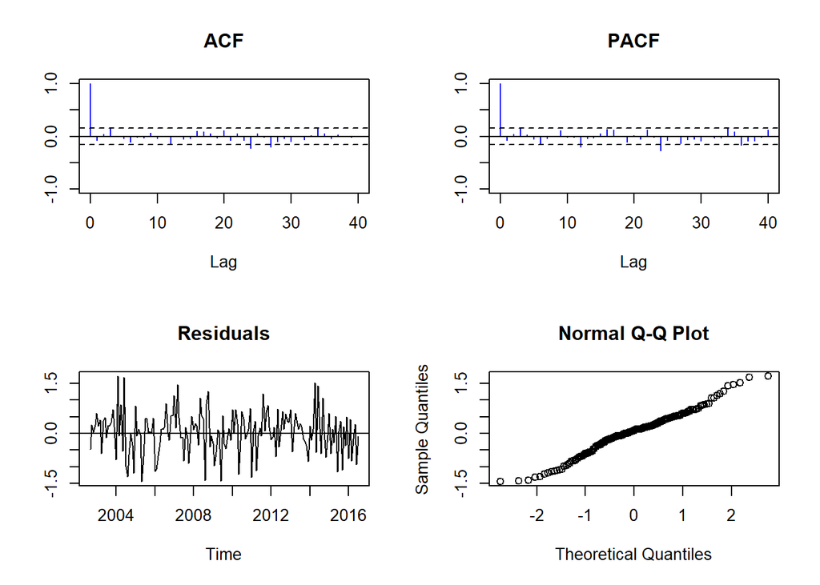

   ```r
   model_3=arma(r2, p=2, q=10)# AICC = 363.8087
   arma_model_03 = specify(ar=model_3$phi, ma = model_3$theta, sigma2 = model_3$sigma2)

   arma_resid_03 = Resid(r2, a=arma_model_03)
   test(arma_resid_03)
   ```

## Model-04

   ```
   Null hypothesis: Residuals are iid noise.
   Test                        Distribution Statistic   p-value
   Ljung-Box Q                Q ~ chisq(20)     18.92    0.5273
   McLeod-Li Q                Q ~ chisq(20)     21.98    0.3419
   Turning points T    (T-110)/5.4 ~ N(0,1)       112    0.7121
   Diff signs S         (S-83)/3.7 ~ N(0,1)        86    0.4227
   Rank P         (P-6930.5)/361.3 ~ N(0,1)      6539    0.2785
   ```

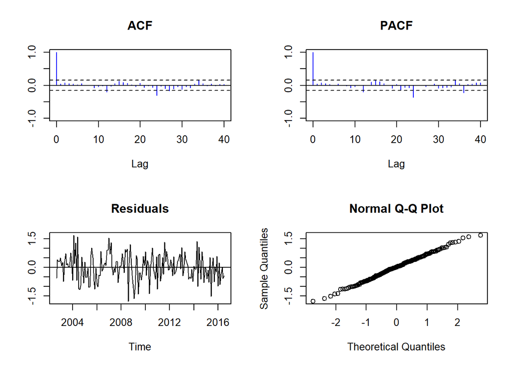

   ```r
   model_4=arma(r2, p=12, q=1) #AICC = 382.1924
   arma_model_04 = specify(ar=model_4$phi, ma = model_4$theta, sigma2 = model_4$sigma2)

   arma_resid_04 = Resid(r2, a=arma_model_04)
   test(arma_resid_04)
   ```

9. Provide the final equation of the best adequate model.

## Model 3 equation:

$$(1 - 0.0884B - 0.6035B^2) \nabla \nabla_{12} X_t =$$

$$(1 + 0.94B -0.09B^2 -0.69B^3 -0.66B^4 -0.10B^5 +0.59B^6 +0.55B^7 -0.08B^8 -0.70B^9 -0.74B^{10})Z_t$$